## **Smoky mouse**

### Blamed on foxes

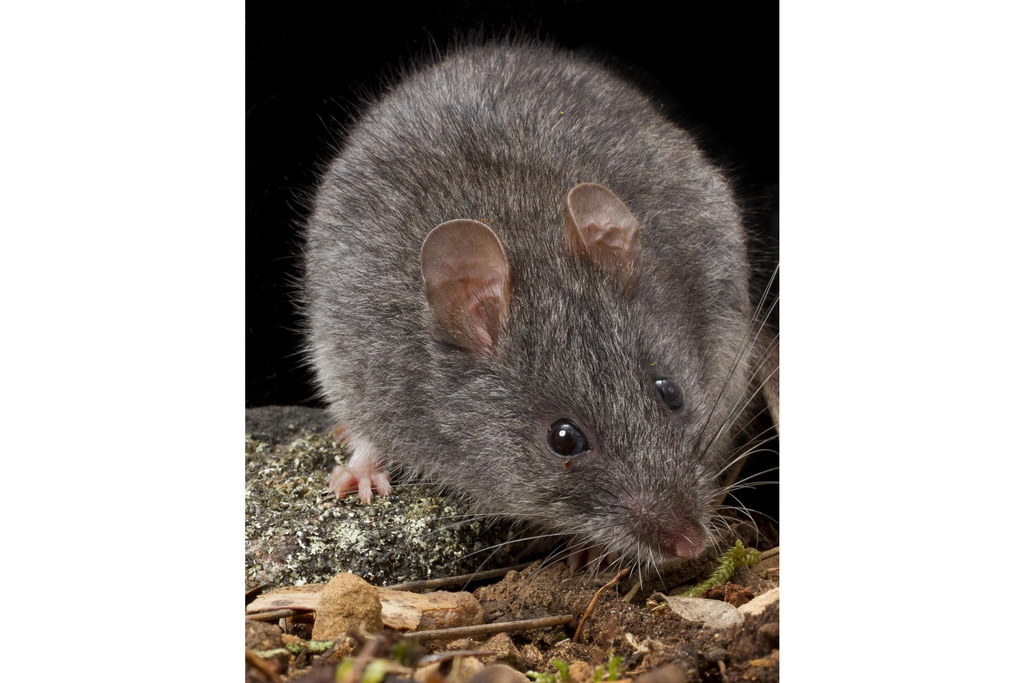

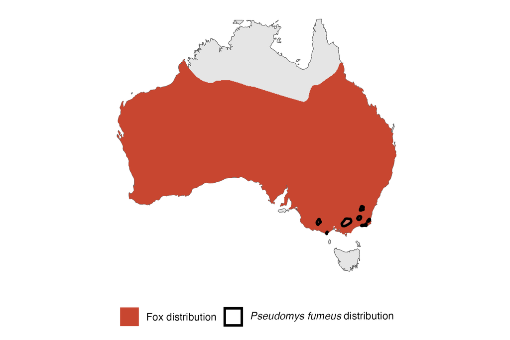

IUCN status: **Vulnerable**

EPBC Predator Threat Rating: **Major**

IUCN claim: *“The species is significantly preyed upon by introduced Red Foxes (Vulpes vulpes), wild dogs (Canis lupus dingo), and feral Domestic Cats (Felis catus).”*

### Studies in support

Smoky mice were found in up to ~1% of the foxes’ diet (Davis et al. 2015).

### Studies not in support

No studies

### Is the threat claim evidence-based?

No studies were found linking foxes to smoky mouse population trends.

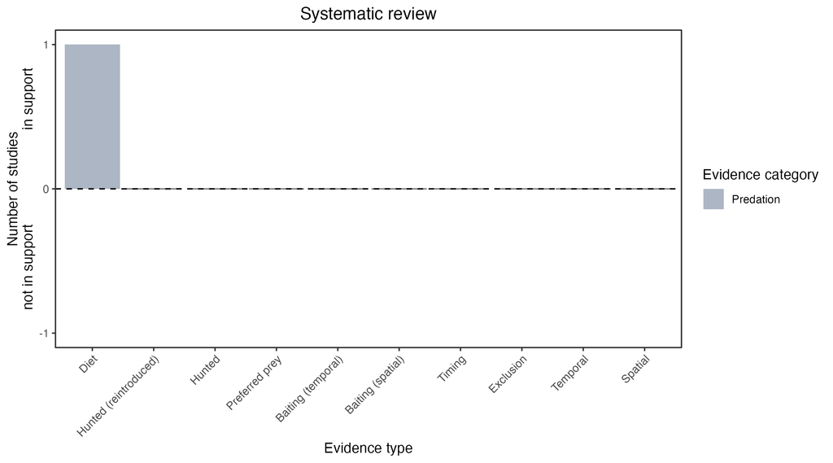

**Evidence linking *Pseudomys fumeus* to foxes.** Systematic review of evidence for an association between *Pseudomys fumeus* and foxes. Positive studies are in support of the hypothesis that *foxes* contribute to the decline of Pseudomys fumeus, negative studies are not in support. Predation studies include studies documenting hunting or scavenging; baiting studies are associations between poison baiting and threatened mammal abundance where information on predator abundance is not provided; population studies are associations between threatened mammal and predator abundance. Gold borders indicate studies that meet qualities of scientific rigour. See methods section in Wallach and Lundgren 2025 for details on evidence categories.

### References

Davis, N.E., Forsyth, D.M., Triggs, B., Pascoe, C., Benshemesh, J., Robley, A., Lawrence, J., Ritchie, E.G., Nimmo, D.G. and Lumsden, L.F., 2015. Interspecific and geographic variation in the diets of sympatric carnivores: dingoes/wild dogs and red foxes in south-eastern Australia. PloS One, 10(3), p.e0120975.

EPBC. (2013) Threat Abatement Plan for Predation by the European Red Fox (2008). Five yearly review. Environment Protection and Biodiversity Conservation Act 1999, Department of the Environment, Water, Heritage and the Arts, Government of Australia (Appendix E: EPBC Act listed threatened species).

IUCN Red List. https://www.iucnredlist.org/ Accessed June 2023

Wallach A.D., Lundgren E.J. (2025) Review of evidence that foxes and cats cause extinctions of Australia’s endemic mammals. BioScience. DOI: 10.1093/biosci/biaf046